# ACR Framework for Remotely Sensed Quantification of Forest Carbon

- Show All Code
- Hide All Code
- View Source

End-to-end pilot demonstration on a synthetic AOI

Author

TÜV SÜD America - Forestry Team

Published

April 14, 2026

## Objective

A reproducible walk-through of ACR’s Framework for Remotely Sensed Quantification of Forest Carbon ([v1.0, 2026](https://acrcarbon.org/program_resources/framework-for-remotely-sensed-quantification-of-forest-carbon/)), applied end-to-end to a synthetic ~5,000 ha forest AOI in the Oregon Cascades. Every numeric input is simulated; no real project data are used. The goal is to show how the Framework’s four stages fit together and to exercise every equation (s.2.4 mean carbon density, s.3.3 Eq. 2, s.3.4 Eqs. 3–6).

This report’s sections follow the ACR Framework below:

1. s.1.4 Spatial scope: define the AOI.
2. s.2 Predictive Model: simulate a pixel raster of aboveground carbon density and a Calibration Plot set used to fit it.
3. s.3.1 Validation plot generation: run the ACR random-point script.
4. s.3.2 Installation: simulate field measurement at each plot.
5. s.3.3 Model eligibility: pair plots with pixels; compute area-weighted average carbon density per plot (Eq. 2).
6. s.3.4 Statistical agreement: RMSE, 90 % CI, uncertainty percentages (Eqs. 3–6); pass/fail the 20 %/10 % thresholds.
7. s.2.4 Mean AOI carbon density: summarize estimates.
8. s.4 Re-measurement prep: audit trail to next reporting period.

```r
library(sf)
library(terra)
library(ggplot2)
library(dplyr)
library(tibble)
library(tidyr)
library(readr)
library(leaflet)
library(htmlwidgets)
library(knitr)

set.seed(20260414)

output_dir <- "outputs_full"
if (!dir.exists(output_dir)) dir.create(output_dir, recursive = TRUE)
```

## 1 Impot AOI

Same synthetic Oregon Cascades polygon used in the validation-plot demo: an irregular ~5,000 ha tract centered near 44.5°N, 122.5°W. Built by perturbing a circle’s radius with sinusoidal plus random noise so the boundary is non-convex and realistic.

```r
centroid_lon <- -122.5
centroid_lat <-   44.5
target_ha    <- 5000

km_per_deg_lat <- 111
km_per_deg_lon <- 111 * cos(centroid_lat * pi / 180)
target_radius_km <- sqrt(target_ha / 100 / pi)

n_vert <- 120
theta  <- seq(0, 2*pi, length.out = n_vert + 1)[-1]
radius_km <- target_radius_km *
  (1 + 0.25 * sin(3*theta) + 0.12 * cos(5*theta) +
       runif(n_vert, -0.06, 0.06))

lon <- centroid_lon + (radius_km * cos(theta)) / km_per_deg_lon
lat <- centroid_lat + (radius_km * sin(theta)) / km_per_deg_lat
coords <- rbind(cbind(lon, lat), c(lon[1], lat[1]))

aoi <- st_sf(name = "Demo AOI",
             geometry = st_sfc(st_polygon(list(coords)), crs = 4326)) |>
  st_make_valid()

aoi_ea <- st_transform(aoi, 6933)  # equal-area for all area computations
aoi_area_ha <- as.numeric(st_area(aoi_ea)) / 1e4
cat(sprintf("AOI area: %.1f ha\n", aoi_area_ha))
```

```
AOI area: 5230.0 ha
```

## 2 Predictive Model

In a real project, a Predictive Model is trained on Calibration Plots (field-measured aboveground carbon) paired with remotely sensed covariates (Landsat/Sentinel/LiDAR/RADAR), then applied to every pixel across the AOI to produce a wall-to-wall map of predicted carbon density (t CO₂e / ha).

For the demo, we skip the regression fit and instead simulate the output of such a model: a 30 m pixel raster of predicted aboveground carbon density over the AOI, with spatial autocorrelation to mimic forest structural variation.

### 2.1 Simulate the pixel-level prediction raster

```r
# Use an equal-area CRS (EPSG:6933) so pixels are truly 30 m × 30 m
aoi_vect <- vect(aoi_ea)
r_template <- rast(ext(aoi_vect), resolution = 30, crs = crs(aoi_vect))

# Coarse smooth field (low-freq sinusoid) + fine noise, clipped to AOI
xy <- xyFromCell(r_template, 1:ncell(r_template))
xn <- (xy[,1] - min(xy[,1])) / (max(xy[,1]) - min(xy[,1]))
yn <- (xy[,2] - min(xy[,2])) / (max(xy[,2]) - min(xy[,2]))

# Simulated AGC density in t CO2e / ha: mean ~ 350, sd ~ 70
agc_vals <- 350 +
  80 * sin(2*pi*xn*1.5) * cos(2*pi*yn*1.2) +
  40 * sin(2*pi*xn*4.0 + 0.7) +
  rnorm(length(xn), 0, 30)
agc_vals <- pmax(agc_vals, 50)

r_pred <- setValues(r_template, agc_vals)
names(r_pred) <- "AGC_tCO2e_per_ha"
r_pred <- mask(r_pred, aoi_vect)

cat(sprintf("Pixels in AOI: %d (%.1f ha)\n",
            global(!is.na(r_pred), "sum")[[1]],
            global(!is.na(r_pred), "sum")[[1]] * 0.09))
```

```
Pixels in AOI: 58790 (5291.1 ha)
```

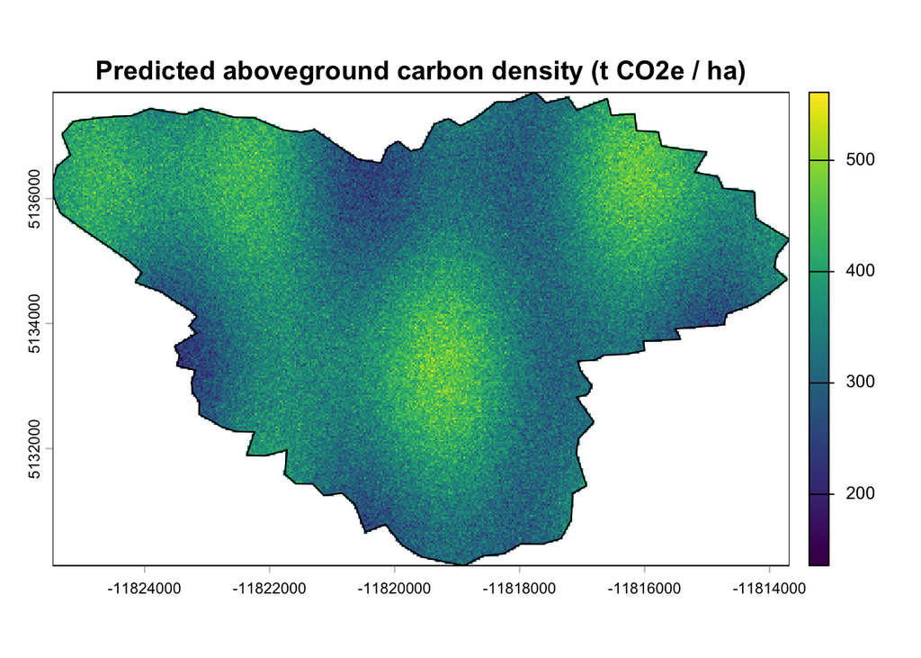

```r
plot(r_pred, main = "Predicted aboveground carbon density (t CO2e / ha)")
plot(aoi_vect, add = TRUE, border = "black", lwd = 1.2)
```

### 2.2 Calibration Plots

```r
n_cal <- 60
cal_pts <- st_sample(aoi, size = n_cal, type = "random", exact = TRUE) |>
  st_as_sf() |>
  mutate(CalID = sprintf("C%02d", dplyr::row_number()))
```

## 3 Validation Plots

### 3.1 Location generation

Inline reproduction of ACR [script](https://acrcarbon.org/wp-content/uploads/2026/03/ACR-Script-for-Validation-Plot-Location-Generation.r) `ACR-Script-for-Validation-Plot- Location-Generation.r`: equal-area sampling in EPSG:6933, `n_points = 45`, ACR-issued seed already set at top of document.

```r
n_points <- 45
poly_sampling <- st_transform(aoi, 6933)
pts_geom <- st_sample(poly_sampling, size = n_points,
                      type = "random", exact = TRUE)
vp <- st_as_sf(pts_geom) |>
  mutate(PointID = sprintf("P%02d", dplyr::row_number())) |>
  st_transform(st_crs(aoi))

vp_ea <- st_transform(vp, 6933)
```

### 3.2 Dummy field measurements

Each Validation Plot is a circular plot of radius 17.84 m (0.1 ha = 1000 m², consistent with FIA subplot-style sampling). The observed aboveground carbon at each plot is the true underlying field sampled with realistic measurement noise and a small positive bias (simulating, for example, a predictive model that slightly under-predicts carbon in mature stands).

```r
plot_radius_m <- 17.84          # 0.1 ha circular plot
vp_polys <- st_buffer(vp_ea, dist = plot_radius_m)

# Predicted area-weighted average carbon density at each plot (s.3.3 Eq. 2)
#   average pixel value weighted by overlap area with the plot
ext_pred <- terra::extract(r_pred, vect(vp_polys),
                           weights = TRUE, fun = NULL)
pred_by_plot <- ext_pred |>
  as_tibble() |>
  group_by(ID) |>
  summarise(C_pred = sum(AGC_tCO2e_per_ha * weight) / sum(weight),
            .groups = "drop") |>
  arrange(ID)

# Simulate observation: truth is the model's prediction plus a realistic
# deviation pattern. This is where a real field crew would walk in with
# diameter tapes / allometric equations.
obs_bias  <- 8     # t CO2e / ha (model under-predicts slightly on average)
obs_noise <- 35    # plot-level residual sd

plots_df <- tibble(
  PointID  = vp$PointID,
  C_pred   = pred_by_plot$C_pred,                         # Ĉ_AVE,AG,p,VP,i
  C_obs    = pred_by_plot$C_pred + obs_bias +
             rnorm(n_points, 0, obs_noise)                # C_AG,VP,i
) |> mutate(residual = C_obs - C_pred)

kable(head(plots_df, 10), digits = 1,
      caption = "Predicted vs. observed carbon density (first 10 plots)")
```

Predicted vs. observed carbon density (first 10 plots)

| PointID | C_pred | C_obs | residual |
| --- | --- | --- | --- |
| P01 | 384.5 | 315.2 | -69.3 |
| P02 | 364.5 | 336.1 | -28.4 |
| P03 | 383.0 | 368.4 | -14.7 |
| P04 | 350.4 | 339.4 | -11.0 |
| P05 | 351.7 | 364.1 | 12.3 |
| P06 | 465.1 | 468.1 | 3.0 |
| P07 | 409.8 | 368.2 | -41.6 |
| P08 | 348.0 | 343.7 | -4.3 |
| P09 | 276.4 | 279.7 | 3.2 |
| P10 | 358.7 | 317.9 | -40.8 |

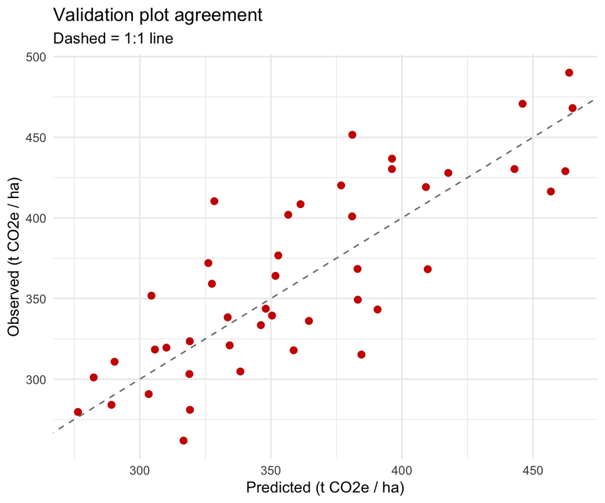

```r
ggplot(plots_df, aes(C_pred, C_obs)) +
  geom_abline(slope = 1, intercept = 0, linetype = 2, color = "grey50") +
  geom_point(color = "red3", size = 2) +
  labs(x = "Predicted (t CO2e / ha)",
       y = "Observed (t CO2e / ha)",
       title = "Validation plot agreement",
       subtitle = "Dashed = 1:1 line") +
  theme_minimal()
```

### 3.3 Assessing model eligibility & equations

ACR Framework s.3.3–3.4 defines four equations. We compute each explicitly.

```r
N   <- nrow(plots_df)
C_obs_bar  <- mean(plots_df$C_obs)
C_pred_bar <- mean(plots_df$C_pred)

# Eq. 3 — Root Mean Squared Error
RMSE <- sqrt(mean((plots_df$C_obs - plots_df$C_pred)^2))

# Eq. 4 — Uncertainty percentage using RMSE  (threshold < 20%)
UNC_RMSE <- (RMSE / C_obs_bar) * 100

# Eq. 5 — 90% Confidence Interval
CI90 <- (RMSE / sqrt(N)) * 1.645

# Eq. 6 — Uncertainty percentage at 90% CI  (threshold <= 10%)
UNC_CI <- (CI90 / C_obs_bar) * 100

tibble(
  Metric = c("N plots","Mean observed C (t CO2e/ha)",
             "Mean predicted C (t CO2e/ha)",
             "RMSE (Eq. 3)","UNC_RMSE % (Eq. 4)",
             "90% CI (Eq. 5)","UNC_CI % (Eq. 6)"),
  Value  = c(N, C_obs_bar, C_pred_bar, RMSE, UNC_RMSE, CI90, UNC_CI)
) |> kable(digits = 2, caption = "Eligibility statistics")
```

Eligibility statistics

| Metric | Value |
| --- | --- |
| N plots | 45.00 |
| Mean observed C (t CO2e/ha) | 364.18 |
| Mean predicted C (t CO2e/ha) | 361.34 |
| RMSE (Eq. 3) | 33.90 |
| UNC_RMSE % (Eq. 4) | 9.31 |
| 90% CI (Eq. 5) | 8.31 |
| UNC_CI % (Eq. 6) | 2.28 |

### 3.4 Statistical agreement

Framework s.3.4: the Predictive Model is eligible when UNC_RMSE < 20 % and UNC_CI ≤ 10 %.

```r
pass_rmse <- UNC_RMSE <  20
pass_ci   <- UNC_CI   <= 10
eligible  <- pass_rmse && pass_ci

tibble(
  Test      = c("UNC_RMSE < 20%", "UNC_CI <= 10%", "Overall eligibility"),
  Observed  = c(sprintf("%.2f%%", UNC_RMSE),
                sprintf("%.2f%%", UNC_CI),
                ifelse(eligible, "PASS", "FAIL")),
  Threshold = c("< 20%", "<= 10%", "both required"),
  Result    = c(ifelse(pass_rmse,"PASS","FAIL"),
                ifelse(pass_ci,  "PASS","FAIL"),
                ifelse(eligible, "ELIGIBLE","NOT ELIGIBLE"))
) |> kable(caption = "ACR s.3.4 agreement test")
```

ACR s.3.4 agreement test

| Test | Observed | Threshold | Result |
| --- | --- | --- | --- |
| UNC_RMSE < 20% | 9.31% | < 20% | PASS |
| UNC_CI <= 10% | 2.28% | <= 10% | PASS |
| Overall eligibility | PASS | both required | ELIGIBLE |

If the test fails, s.3.4 allows the Project Proponent either to install additional Validation Plots from the same sequence (pending ACR approval) or to discontinue and request a fresh seed to restart s.3.

## 4 AOI-level mean carbon density

The pixel raster gives the Framework’s primary deliverable: AOI-level mean aboveground carbon density (used for crediting once the model is approved).

```r
mean_C <- global(r_pred, "mean", na.rm = TRUE)[[1]]
total_C <- mean_C * aoi_area_ha   # t CO2e across the whole AOI

tibble(
  Quantity = c("AOI area (ha)",
               "Mean AGC density (t CO2e / ha)",
               "Total AGC stock (t CO2e)"),
  Value    = c(aoi_area_ha, mean_C, total_C)
) |> kable(digits = 1, caption = "AOI-level roll-up (s.2.4)")
```

AOI-level roll-up (s.2.4)

| Quantity | Value |
| --- | --- |
| AOI area (ha) | 5230.0 |
| Mean AGC density (t CO2e / ha) | 354.8 |
| Total AGC stock (t CO2e) | 1855738.2 |

## 5 Interactive map

AOI outline, predictive raster thumbnail, Calibration Plots (blue), Validation Plot centers (red).

```r
# Raster to WGS84 for web display (build a target template explicitly
# because auto-projection from an equal-area CRS occasionally fails to
# infer output extent)
aoi_wgs_vect <- vect(aoi)
r_tmpl_wgs <- rast(aoi_wgs_vect, resolution = 0.0005)
crs(r_tmpl_wgs) <- "EPSG:4326"
r_wgs <- project(r_pred, r_tmpl_wgs, method = "bilinear")
pal <- colorNumeric("YlGn", values(r_wgs), na.color = "transparent")

leaf <- leaflet() |>
  addProviderTiles(providers$Esri.WorldImagery, group = "Imagery") |>
  addProviderTiles(providers$CartoDB.Positron,  group = "Basemap") |>
  addRasterImage(r_wgs, colors = pal, opacity = 0.7,
                 group = "Predicted AGC") |>
  addPolygons(data = aoi, fill = FALSE, color = "#222",
              weight = 2, group = "AOI") |>
  addCircleMarkers(data = st_transform(cal_pts, 4326),
                   radius = 3, color = "blue", fillOpacity = 0.8,
                   label = ~CalID, group = "Calibration plots") |>
  addCircleMarkers(data = st_transform(vp, 4326),
                   radius = 5, color = "red", fillOpacity = 0.9,
                   label = ~PointID, group = "Validation plots") |>
  addLegend(pal = pal, values = values(r_wgs),
            title = "AGC (t CO2e/ha)", opacity = 0.8) |>
  addLayersControl(
    baseGroups = c("Basemap","Imagery"),
    overlayGroups = c("AOI","Predicted AGC",
                      "Calibration plots","Validation plots"),
    options = layersControlOptions(collapsed = FALSE)
  ) |>
  hideGroup("Calibration plots")

html_path <- file.path(output_dir, "full_framework_map.html")
saveWidget(leaf, file = normalizePath(html_path, mustWork = FALSE),
           selfcontained = TRUE)
leaf
```

[interactive chart not shown]

## 6 Re-measurements

Once the Predictive Model is deemed eligible, s.4 of the Framework kicks in at the next reporting period: the VVB may remeasure a subset of the existing Validation Plots to confirm stability, or the Project Proponent may request a new seed to draw a fresh sequence if conditions in the AOI have changed materially (disturbance, harvest, regrowth). The same script and the same 20 %/10 % thresholds apply.

## 7 Exports

```r
write_csv(plots_df, file.path(output_dir, "validation_plots_eligibility.csv"))
writeRaster(r_pred, file.path(output_dir, "predicted_agc.tif"),
            overwrite = TRUE)
suppressWarnings(st_write(vp, file.path(output_dir, "validation_points.shp"),
                          delete_layer = TRUE, quiet = TRUE))
suppressWarnings(st_write(cal_pts,
                          file.path(output_dir, "calibration_points.shp"),
                          delete_layer = TRUE, quiet = TRUE))
```

- `outputs_full/predicted_agc.tif` — simulated pixel prediction raster
- `outputs_full/validation_points.shp` — 45 plot centers
- `outputs_full/calibration_points.shp` — 60 simulated calibration plots
- `outputs_full/validation_plots_eligibility.csv` — predicted vs. observed
- `outputs_full/full_framework_map.html` — standalone interactive map

#### Notes

The Predictive Model here is a hand-crafted spatial field, not a fitted regression on real covariates; the observation process is Gaussian noise plus a constant bias rather than real allometric error; and the Calibration Plots are decorative. Everything downstream of the raster, including the ACR script, the equal-area sampling, the plot-pixel overlap, the RMSE and CI computations, the s.3.4 decision, demostrates a typical project runtime.